# Topographic refugia from mountain pine beetle, and why terrain-derived wind surfaces cannot find them at small extents

Testing refugia hypotheses across a 1,776 m relief gradient in the Selkirk Mountains of British Columbia

Author

Seamus Murphy

Published

August 3, 2026

Abstract

Keywords

disturbance refugia, mountain pine beetle, aerial overview survey, Global Wind Atlas, scale dependence, collinearity

```r
## Every quantity in this manuscript is computed here at render time.
## patchwork is loaded for its `+` operator on ggplots (@fig-gradient), which is
## why no patchwork function appears by name anywhere below.
pkgs <- c("terra","knitr","kableExtra","ggplot2","dplyr","patchwork","tibble")
invisible(lapply(pkgs, function(p) library(p, character.only = TRUE)))
## dpi 300 is the Elsevier minimum for a combination line/halftone figure.
knitr::opts_chunk$set(echo = TRUE, message = FALSE, warning = FALSE, error = TRUE,
                      comment = NA, dpi = 300, fig.align = "center")
options(scipen = 999)
theme_set(theme_minimal(base_size = 10) +
          theme(panel.grid.minor = element_blank(),
                plot.title = element_text(face = "bold", size = 10)))

B_BOOT   <- 150L    # spatial block bootstrap replicates
BLOCK    <- 40L     # block side in cells (40 x 25.1 m ~= 1 km)
OUTBREAK <- 1999:2015
```

```r
DATA_ROOT <- Sys.getenv("DARKWOODS_DATA",
  "/Users/seamus/repos/publications-pending/Darkwoods-Disturbance-Paper/3.SpatialData")
dpath <- function(...) file.path(DATA_ROOT, ...)
here  <- function(...) file.path("..", ...)     # repo-relative, from 01.manuscript/
stopifnot(dir.exists(dpath("terrain_environment")))

## The elevation surface is the analysis grid: everything else is resampled onto
## it. Loaded here so the Study area section can quote the relief from the raster
## rather than from memory.
G <- rast(dpath("terrain_environment", "Elevation.utm.tif"))
GRID_RELIEF <- diff(as.vector(minmax(G)))
```

# 1 Introduction

Disturbance refugia, defined by Krawchuk et al. (2020) as locations disturbed less severely or less frequently than the surrounding landscape, have become a organising concept for forest conservation under climate change. The concept is well developed for fire and much less so for insects. Krawchuk et al. (2020) note that few studies have explicitly identified refugia from insect outbreaks, and they propose a specific and testable mechanism for the most consequential insect disturbance in western North America. Refugia from mountain pine beetle (*Dendroctonus ponderosae* Hopkins), they suggest, could occur in areas of lower host density, where thinner stands allow greater wind penetration and so disrupt the aggregation pheromone communication on which mass attack depends.

The hypothesis is attractive because it is mechanistic and because each of its parts is independently plausible. Mass attack requires beetles to overwhelm host defences in a coordinated pulse, and the coordination is chemical. Beetle dispersal above the canopy is a flight behaviour sensitive to ambient conditions (Gray, Billings, Gara, & Johnsey, 1972; Jones, Shegelski, Marculis, Wijerathna, & Evenden, 2019). Thinner stands admit more wind. What has been missing is a spatial test.

Cartwright (2018) came closest. Working at 30 m in lodgepole and whitebark pine in southern Oregon, she identified refugia from Landsat moisture anomalies during a 2009 drought and mountain pine beetle outbreak and modelled their landscape controls. Refugia were associated with topographically shaded slopes, convergent positions such as valleys, low soil bulk density, and thinner stands. The thinner-stand result is the host-density half of the hypothesis, confirmed. But she had no wind surface, so the mechanism itself went untested.

Testing it requires a wind surface, and that is where the problem starts. Gridded wind products of the kind now trivially available, the Global Wind Atlas among them, are produced by downscaling coarse mesoscale fields over a digital elevation model (Badger, Frank, Hahmann, & Giebel, 2014; Technical University of Denmark (DTU) Wind Energy and World Bank Group, n.d.). A wind surface built this way is in part a transform of the terrain it was draped over. Offered to a model alongside elevation it is not an independent measurement, and the severity of the dependence is a function of the analysis extent: a coarse driving field is nearly flat over a few kilometres, so at small extents almost all the variation in the product is terrain. An analyst working at the scale of a burn perimeter or a cluster of field plots, which is the scale at which most disturbance ecology is done, is in the worst position and has the least warning.

A second and more elementary trap attends refugia work specifically. A cell that was not attacked may hold no host. Under the Krawchuk et al. (2020) framing this is the difference between asking what a place is a refugium *from* and what it is a refugium *for*, and it cannot be resolved without an independent map of host abundance. The precedent here is old and pointed: Hadley (1994) predicted heavier beetle mortality on hot, dry, south-facing slopes and found the reverse, because host density rather than moisture stress governed where attack succeeded.

We take these three problems to one landscape. We ask:

1. Does terrain condition beetle-caused mortality once host abundance is accounted for, and where along the elevation gradient does host stop explaining the pattern?
2. Does the component of the wind surface that is independent of elevation predict reduced attack where host is present, as Krawchuk et al. (2020) hypothesise?
3. How much does the answer to question 2 depend on decisions the analyst makes freely: the extent of the study area, the grain of the cells, and whether damage is coded as a binary or as the ordinal severity class the survey records?

The design is built to make the third question answerable rather than rhetorical. The same response, the same predictors and the same model are refitted across each of those three axes: once across the full landscape and once inside a 2 by 4 km clip drawn from it, at 25 m, 50 m and 100 m, and at each severity threshold in turn. Two of the three change the answer, and they are not the two that get reported.

# 2 Materials

## 2.1 Study area

The Darkwoods Conservation Area lies in the South Selkirk Mountains of southeastern British Columbia. The terrain grid spans 16 by 17.5 km and **1,776 m of relief**, from valley bottom to alpine. The modelled area is a subset of it, because cells carrying no inventory basal area cannot enter a model that conditions on stand structure; Table 1 reports the extent and relief of that subset, which are necessarily smaller. Both numbers are correct and they are not interchangeable. That range crosses the full biogeoclimatic sequence of the southern interior wet belt, from the dry warm Interior Cedar-Hemlock subzones through the moist warm subzones to the Engelmann Spruce-Subalpine Fir zone and its parkland variant (Braumandl & Dykstra, 2005; Ketcheson et al., 1991). Lodgepole pine (*Pinus contorta* var. *latifolia*), the beetle’s principal host here, occupies the middle of that sequence and is scarce at both ends.

The site description and the terrain surfaces are inherited from a companion analysis of conifer regeneration on the same ground (Murphy, Leslie, Banks, & Wilson, 2024), which used them to predict seedling intensity after a 2015 mixed-severity wildfire. Disturbance was a predictor in that study. Here it is the response.

## 2.2 Beetle-caused mortality

```r
aos_box <- ext(project(as.polygons(ext(G), crs = crs(G)), "EPSG:3005"))
aos <- vect(here("02.inputs/aos/pest_infestation_poly.gdb"),
            layer = "pest_infestation_poly", extent = aos_box)
mpb <- project(aos[aos$PEST_SPECIES_CODE == "IBM", ], crs(G))   # IBM = mountain pine beetle
m   <- mpb[mpb$CAPTURE_YEAR %in% OUTBREAK, ]

## BC severity classes are ordinal: trace, light, moderate, severe, very severe
sev_rank <- c(T = 1, L = 2, M = 3, S = 4, V = 5)
m$sev <- unname(sev_rank[m$PEST_SEVERITY_CODE]); m$sev[is.na(m$sev)] <- 0

severity  <- rasterize(m, G, field = "sev", fun = "max", background = 0)

c(polygons = nrow(m), years = length(unique(m$CAPTURE_YEAR)),
  hectares = round(sum(m$AREA_HA)))
```

```
polygons    years hectares
     301       14     7920
```

The response is the British Columbia Aerial Overview Survey, the operational provincial record of forest health, in which observers sketch-map damage annually from fixed-wing aircraft and label each polygon by year, causal agent, severity class and host species. We take polygons coded `IBM`, mountain pine beetle, for the outbreak window 1999 to 2015, and rasterise the maximum severity class reached by each cell.

Using the survey rather than a spectral classification is a deliberate trade. Red attack has been mapped from Landsat with respectable and improving accuracy (Meddens, Hicke, Vierling, & Hudak, 2013; White, Wulder, Brooks, Reich, & Wheate, 2005; Ye et al., 2021), but every such product is a model whose errors are spatially structured and not independent of terrain, because illumination, shadow and view angle all vary with slope and aspect. For a question about terrain, a response generated by a terrain-sensitive classifier risks recovering the classifier’s own terrain sensitivity. Sketch-mapping has larger and cruder errors, but they are observer errors, not errors generated by the predictors under test.

The severity scale is anchored to ground measurement. Twenty-eight field plots established in beetle-affected stands in 2020 recorded the basal area of pine killed, spanning 0.6 to 47.4 m2/ha, or 1.3 to 94.7 per cent of plot basal area, and these calibrated the spectral mapping used in the companion study (Murphy et al., 2024). Plot coordinates were not recoverable from the project archive, so the plots calibrate the severity scale but cannot be used to check the spatial placement of individual survey polygons. We state that limit rather than implying a spatial validation we did not perform.

## 2.3 Host abundance

```r
vri <- project(vect(here("02.inputs/vri/vri_darkwoods.geojson")), crs(G))
vd  <- as.data.frame(vri)
num <- function(x) suppressWarnings(as.numeric(x))

## VRI records up to three species per polygon with percentage cover
accumulate <- function(pattern) {
  out <- rep(0, nrow(vd))
  for (i in 1:3) {
    cd <- vd[[paste0("SPECIES_CD_", i)]]
    pc <- num(vd[[paste0("SPECIES_PCT_", i)]]); pc[is.na(pc)] <- 0
    out <- out + ifelse(!is.na(cd) & grepl(pattern, cd), pc, 0)
  }
  out
}
vri$PinePct <- accumulate("^PL")               # lodgepole, the primary host
vri$Basal   <- num(vd$BASAL_AREA)

host <- rast(lapply(c("PinePct","Basal"), function(f) rasterize(vri, G, field = f)))
names(host) <- c("PinePct","Basal")
c(vri_polygons = nrow(vri), with_lodgepole = sum(vri$PinePct > 0))
```

```
  vri_polygons with_lodgepole
          2743           1024
```

Host abundance comes from the provincial Vegetation Resources Inventory, layer `VEG_COMP_LYR_R1_POLY`, retrieved from the British Columbia Data Catalogue web feature service for the study window. We accumulate the percentage cover of lodgepole pine across the three species slots each polygon records, and carry stand basal area alongside it.

Without this layer the analysis cannot distinguish a refugium from an absence of pine, and Section 4.1 shows that the distinction accounts for most of the apparent terrain signal.

## 2.4 Terrain and wind

```r
to_grid <- function(f) {
  r <- rast(dpath("terrain_environment", f))
  b <- project(as.polygons(ext(G), crs = crs(G)), crs(r))
  project(crop(r, b, snap = "out"), G, method = "bilinear")
}
terr <- rast(list(Elevation = G,               Slope = to_grid("Slope.utm.tif"),
                  TWI       = to_grid("TWI.utm.tif"),
                  RIX       = to_grid("Rutm.tif"),
                  Wind      = to_grid("Wind.utm.tif")))
names(terr) <- c("Elevation","Slope","TWI","RIX","Wind")

## Topographic position: mean deviation from a surrounding annulus.
tpi <- function(r, w) {
  k <- matrix(1, w, w); k[ceiling(w/2), ceiling(w/2)] <- 0
  r - focal(r, k / sum(k), fun = sum, na.policy = "omit", na.rm = TRUE)
}
terr$TPI600 <- tpi(G, 25)     # ~625 m neighbourhood
```

```r
## Two surfaces built from aspect, which the inherited set lacks entirely.
## Both are computed directly from the elevation model rather than draped over
## it, which is why @tbl-orthogonality can show them independent of elevation.
d2r <- pi / 180
asp  <- rast(dpath("terrain_environment", "Aspect.utm.tif"))
slp  <- rast(dpath("terrain_environment", "Slope.utm.tif"))
stopifnot(identical(dim(asp), dim(G)), identical(as.vector(ext(asp)), as.vector(ext(G))))

## Heat load after McCune and Keon, aspect folded about the SW-NE axis so that
## southwest is hottest. Flat cells carry a -1 sentinel; the sin(slope) factor
## nulls the aspect term there, so the substitution below is inert.
asp[asp < 0] <- 225
fold <- abs(180 - abs(asp - 225))
LAT  <- mean(crds(project(as.polygons(ext(G), crs = crs(G)), "EPSG:4326"))[, 2])
terr$HLI <- 0.339 + 0.808 * cos(LAT*d2r) * cos(slp*d2r) -
            0.196 * sin(LAT*d2r) * sin(slp*d2r) -
            0.482 * cos(fold*d2r) * sin(slp*d2r)

## Winstral shelter index: the maximum upwind slope angle within SEARCH metres
## along a bearing. Positive means terrain rises upwind, so the cell is
## sheltered; negative means it is exposed. The Global Wind Atlas gives speed
## but no direction, so rather than assume a prevailing bearing we compute all
## eight and average, giving an omnidirectional shelter index.
SEARCH <- 500
shift_mat <- function(m, dr, dc) {
  nr <- nrow(m); nc <- ncol(m); out <- matrix(NA_real_, nr, nc)
  ri <- seq_len(nr); ci <- seq_len(nc); sr <- ri + dr; sc <- ci + dc
  vr <- sr >= 1 & sr <= nr; vc <- sc >= 1 & sc <= nc
  out[ri[vr], ci[vc]] <- m[sr[vr], sc[vc]]
  out
}
zm <- as.matrix(G, wide = TRUE); rstep <- res(G)[1]
sx_dir <- function(az) {
  th <- az * d2r; best <- matrix(-Inf, nrow(zm), ncol(zm))
  for (k in 1:floor(SEARCH / rstep)) {
    dc <- round(k * sin(th)); dr <- round(-k * cos(th))
    if (dc == 0 && dr == 0) next
    best <- pmax(best, atan((shift_mat(zm, dr, dc) - zm) / (k * rstep)) / d2r, na.rm = TRUE)
  }
  best[!is.finite(best)] <- NA_real_
  best
}
sx <- rast(lapply(seq(0, 315, by = 45), function(a) {
  r <- G; values(r) <- as.vector(t(sx_dir(a))); r }))
terr$SxMean <- app(sx, mean, na.rm = TRUE)
```

Terrain surfaces are inherited unchanged from Murphy et al. (2024), which derived them from the 1 m Natural Resources Canada High Resolution Digital Elevation Model (Natural Resources Canada, 2017), smoothed, depression-filled by the algorithm of Wang & Liu (2006) and aggregated to 25 m, with compound indices following Beers & Miller (1973) and Parker (1982). We add three surfaces of our own. The first is a topographic position index at a 625 m neighbourhood, because Cartwright (2018) found topographic position among the strongest controls on refugia and it was absent from the inherited set.

The other two exist because the inherited set carries no aspect information at all, and so contains no term that can distinguish a warm slope from a cold one at the same elevation. That matters here specifically, because the confound this paper cannot resolve is between wind exposure and cold, and aspect bears on the two differently. We therefore compute a heat load index after McCune & Keon (2002), in which aspect is folded about the southwest to northeast axis so that southwest is hottest, and a shelter index after Winstral, Elder, & Davis (2002), the maximum upwind slope angle within 500 m along a bearing, which is positive where terrain rises upwind and negative on exposed convexities. The Global Wind Atlas supplies speed but no direction, so rather than assume a prevailing bearing we compute the shelter index on all eight cardinal and intercardinal bearings and average them, giving an omnidirectional index that requires no assumption about wind direction.

The decisive property of both is how they are built. They are derived from the elevation model by trigonometry rather than draped over it by downscaling, and Table 2 shows the consequence: their variance is essentially unrelated to elevation, where the wind product’s is largely elevation. A terrain-derived predictor is not automatically an elevation transform. The distinction is in the construction, not in the fact of using a digital elevation model.

The ruggedness surface carries a documentation gap we state rather than paper over. Its exact formulation is not recorded beyond the citations above, and its distribution is inconsistent with a vector ruggedness measure. We treat it as a reproducible but unnamed ruggedness surface and confine claims to its statistical behaviour.

Ambient wind is Global Wind Atlas mean wind speed (Technical University of Denmark (DTU) Wind Energy and World Bank Group, n.d.), produced by generalising and downscaling mesoscale model output over terrain elevation and roughness (Badger et al., 2014). That construction is why it cannot be assumed independent of elevation, and testing that assumption is the second half of this paper.

## 2.5 Station temperature records

Because the interpretation in Section 4.2 turns on whether it is cold enough at the top of the gradient to kill beetles, we assembled the observational record that bears on it. Hourly observations from the British Columbia Wildfire Service network and daily observations from the Environment and Climate Change Canada network were retrieved for all stations within 100 km of the study area for the winters of the outbreak window. Retrieval is done by the script in `02.inputs/climate/`, which streams roughly 2.7 GB of hourly and daily observations and writes the per-station-winter summary the manuscript reads. That division is deliberate: the network fetch and the reduction of hourly series to winter summaries cannot sit inside a document render, but every decision about which records to believe is made in Section 4.5, in code, and is visible there.

Two screens matter. Many older Wildfire Service sensors floor at exactly -20.0 °C, so a station-winter whose minimum sits exactly on that floor has an unknown true minimum and is excluded; the rule is applied and checked in Section 4.5 rather than inherited. Isolated single-observation spikes, colder than both neighbouring observations by more than 15 °C, are rejected as instrument error at the observation level, which is the one screen that must happen during retrieval because it needs the sub-daily series. One such value, a -40.0 °C daily minimum recorded on a day whose maximum was -4.5 °C and carrying no quality flag, would otherwise have produced exactly the conclusion the record does not support.

This network cannot furnish a temperature surface, for the reasons Section 4.5 sets out. It can establish whether lethal temperatures occur in this region at all, which is a weaker claim and a sufficient one.

```r
clip_src <- rast(dpath("beetle_stages", "Beetle.Oubteak.2005.tif"))
in_clip  <- rasterize(project(as.polygons(ext(clip_src), crs = crs(clip_src)), crs(G)),
                      G, field = 1, background = 0)

X <- as.data.frame(c(terr, host, severity, in_clip), na.rm = FALSE)
names(X)[(ncol(X) - 1):ncol(X)] <- c("Severity","InClip")
X$Attacked <- X$Severity > 0
X$HasHost  <- !is.na(X$PinePct) & X$PinePct > 0

## spatial blocks for resampling-based inference
rc <- rowColFromCell(G, seq_len(ncell(G)))
X$block <- paste(rc[,1] %/% BLOCK, rc[,2] %/% BLOCK, sep = "_")

PRED  <- c("Elevation","Slope","TWI","RIX","Wind","TPI600")
EXTRA <- c("HLI","SxMean")          # aspect-derived; enter only the extended model
MVARS <- c(PRED, "PinePct", "Basal")   # defines the analysis frame, deliberately unchanged

## Cells lacking an inventory basal area are unmapped or non-productive and cannot
## enter a model that conditions on stand structure. Dropping them is reported here
## rather than left to silent na.action inside glm.
n_before <- sum(complete.cases(X[, PRED]) & !is.na(X$PinePct))
S <- X[complete.cases(X[, MVARS]), ]
H <- S[S$HasHost, ]
c(with_terrain_and_host = n_before, dropped_no_basal_area = n_before - nrow(S),
  analysis_cells = nrow(S), km2 = round(nrow(S) * prod(res(G)) / 1e6, 1),
  attacked = sum(S$Attacked), host_cells = nrow(H))
```

```
with_terrain_and_host dropped_no_basal_area        analysis_cells
             388003.0              121353.0              266650.0
                  km2              attacked            host_cells
                168.2               55713.0              127604.0
```

```r
tibble(
  Extent = c("full landscape", "2 by 4 km clip"),
  Cells  = c(nrow(S), sum(S$InClip == 1)),
  `Area (km²)` = round(c(nrow(S), sum(S$InClip == 1)) * prod(res(G)) / 1e6, 1),
  `Elevation (m)` = c(sprintf("%.0f to %.0f", min(S$Elevation), max(S$Elevation)),
                      sprintf("%.0f to %.0f", min(S$Elevation[S$InClip==1]),
                                              max(S$Elevation[S$InClip==1]))),
  `Relief (m)` = round(c(diff(range(S$Elevation)), diff(range(S$Elevation[S$InClip==1])))),
  `Attacked (%)` = round(100 * c(mean(S$Attacked), mean(S$Attacked[S$InClip==1])), 1)
) |> kable(booktabs = TRUE, align = "lrrlrr", format.args = list(big.mark = ",")) |>
  kable_styling(full_width = FALSE, font_size = 11)
```

| Extent | Cells | Area (km²) | Elevation (m) | Relief (m) | Attacked (%) |
| --- | --- | --- | --- | --- | --- |
| full landscape | 266,650 | 168.2 | 528 to 2268 | 1,740 | 20.9 |
| 2 by 4 km clip | 9,784 | 6.2 | 654 to 1747 | 1,093 | 45.3 |

# 3 Methods

## 3.1 Inference

The response is heavily clustered, so cell counts vastly overstate independent information. All coefficients are accompanied by percentile intervals from a spatial block bootstrap in which the landscape is partitioned into blocks of 40 by 40 cells, roughly 1 km on a side, and blocks are resampled with replacement 150 times. Blocks of this size are larger than any plausible correlation range of the survey polygons. We report the point estimate, the block interval, and the proportion of resamples reproducing the sign of the point estimate, and we treat a term as supported only when the interval excludes zero.

```r
## The bootstrap refits several hundred times on >100,000 rows, so it works on a
## model matrix built once and calls glm.fit directly. This is arithmetically
## identical to glm() with the same formula, and roughly thirty times faster.
MODEL_VARS <- c("Elevation","WindResid","PinePct","Basal","TPI600","Slope","TWI","RIX")

design_matrix <- function(z, vars = MODEL_VARS)
  cbind(`(Intercept)` = 1, as.matrix(z[, vars, drop = FALSE]))

fit_fast <- function(Xm, y) glm.fit(Xm, y, family = binomial())

block_boot <- function(z, vars = MODEL_VARS, B = B_BOOT, seed = 42) {
  Xm <- design_matrix(z, vars); y <- z$y
  idx_of <- split(seq_len(nrow(z)), z$block)
  blocks <- names(idx_of)
  set.seed(seed)
  out <- matrix(NA_real_, B, ncol(Xm), dimnames = list(NULL, colnames(Xm)))
  for (b in seq_len(B)) {
    idx <- unlist(idx_of[sample(blocks, length(blocks), replace = TRUE)], use.names = FALSE)
    f <- try(fit_fast(Xm[idx, , drop = FALSE], y[idx]), silent = TRUE)
    if (!inherits(f, "try-error")) out[b, ] <- coef(f)
  }
  out
}

model_table <- function(z, vars = MODEL_VARS, seed = 42) {
  Xm <- design_matrix(z, vars)
  fit <- fit_fast(Xm, z$y)
  cf  <- coef(fit)
  se  <- sqrt(diag(chol2inv(fit$qr$qr[1:fit$rank, 1:fit$rank, drop = FALSE])))
  bs  <- block_boot(z, vars, seed = seed)
  tibble(term = names(cf), beta = as.numeric(cf), naive_z = as.numeric(cf / se),
         lo = apply(bs, 2, quantile, .025, na.rm = TRUE),
         hi = apply(bs, 2, quantile, .975, na.rm = TRUE),
         sign_stab = sapply(names(cf), function(n)
                       mean(sign(bs[, n]) == sign(cf[n]), na.rm = TRUE)))
}

fmt_model <- function(mt) {
  mt |> filter(term != "(Intercept)") |>
    transmute(Term = term, beta = sprintf("%+.3f", beta),
              `naive z` = sprintf("%+.1f", naive_z),
              `block 95% CI` = sprintf("[%+.3f, %+.3f]", lo, hi),
              `sign stability` = sprintf("%.2f", sign_stab),
              Supported = ifelse(lo * hi > 0, "yes", "no"))
}
```

## 3.2 Orthogonalisation

Because the wind surface is built over the elevation surface, its coefficient in a model that also contains elevation is estimated from whatever small part of the joint distribution allows the two to vary separately, and it is not interpretable as an effect of wind. We therefore replace wind by the residual of wind regressed on elevation, rescaled to unit variance. This is a linear reparameterisation, so fitted values and deviance are unchanged; what changes is that the coefficient now refers to the part of the wind surface that elevation does not explain. That is the quantity the Krawchuk et al. (2020) hypothesis is about.

```r
standardise <- function(dd) {
  vars <- intersect(c(PRED, EXTRA, "PinePct", "Basal"), names(dd))
  z <- as.data.frame(scale(dd[, vars]))
  z$y     <- as.integer(dd$Attacked)
  z$block <- dd$block
  z$Severity <- dd$Severity          # carried for the ordinal fits in @sec-ordinal
  z$WindResid <- as.numeric(scale(residuals(lm(Wind ~ Elevation, data = z))))
  z
}
Z  <- standardise(S)     # whole landscape
ZH <- standardise(H)     # cells containing lodgepole
ZC <- standardise(S[S$InClip == 1, ])   # the 2 by 4 km clip
round(cor(Z[, c("Elevation","Wind","WindResid")]), 3)
```

```
          Elevation  Wind WindResid
Elevation     1.000 0.793     0.000
Wind          0.793 1.000     0.609
WindResid     0.000 0.609     1.000
```

```r
tibble(Surface = c("Global Wind Atlas wind speed", "Heat load index (McCune and Keon)",
                   "Shelter index (Winstral, omnidirectional)", "Topographic position, 625 m"),
       `How it is built` = c("mesoscale field downscaled over the DEM",
                             "trigonometric function of DEM aspect and slope",
                             "maximum upwind slope from the DEM within 500 m",
                             "deviation from surrounding DEM mean"),
       `R² on elevation` = sapply(c("Wind","HLI","SxMean","TPI600"), function(v)
         round(summary(lm(as.formula(paste(v, "~ Elevation")), data = Z))$r.squared, 3))) |>
  kable(booktabs = TRUE, align = "llr") |>
  kable_styling(full_width = FALSE, font_size = 10)
```

Table 2: How much of each candidate predictor is elevation. The wind product is a downscaled mesoscale field draped over terrain and is largely an elevation transform. The heat load and shelter indices are computed from the same elevation model by trigonometry and are almost unrelated to it. Being terrain-derived and being an elevation transform are not the same thing.

| Surface | How it is built | R² on elevation |
| --- | --- | --- |
| Global Wind Atlas wind speed | mesoscale field downscaled over the DEM | 0.629 |
| Heat load index (McCune and Keon) | trigonometric function of DEM aspect and slope | 0.000 |
| Shelter index (Winstral, omnidirectional) | maximum upwind slope from the DEM within 500 m | 0.002 |
| Topographic position, 625 m | deviation from surrounding DEM mean | 0.021 |

## 3.3 Response coding

Krawchuk et al. (2020) warn specifically against coding refugia as a binary, on the grounds that a refugium is a matter of degree and that thresholding discards the part of the signal that distinguishes a lightly touched stand from a destroyed one. The survey carries an ordinal severity class, so we can follow that advice. We fit the binary attacked model above for comparability with the refugia literature, and alongside it a cumulative logit at each severity threshold: the probability that a cell reached trace or worse, light or worse, moderate or worse, and severe or worse. Fitting the thresholds separately rather than imposing a single proportional-odds slope is deliberate. It is also the standard diagnostic for whether proportional odds holds, and Section 4.3 shows that here it does not.

## 3.4 Grain

Extent is varied by design in Section 4.6, but grain is a separate axis and Work, St. Onge, & Jacobs (2011) show that terrain derivatives are sensitive to it, because the error in a digital elevation model propagates into slope and curvature differently at every resolution. A referee will ask. We therefore repeat the host-present model at 25 m, 50 m and 100 m, aggregating the predictors by mean and the severity class by maximum, holding the topographic position neighbourhood near-constant in metres rather than in cells so that it remains the same variable, and rescaling the bootstrap blocks so they stay near 1 km at every grain.

# 4 Results

## 4.1 Attack is unimodal, and below 1,900 m the hump is host

```r
S$band <- cut(S$Elevation, breaks = seq(500, 2400, 200), dig.lab = 5)
grad <- S |> group_by(band) |>
  summarise(Cells = n(),
            `Pine cover (%)` = round(mean(PinePct), 1),
            `Basal area` = round(mean(Basal, na.rm = TRUE), 1),
            `Wind (m/s)` = round(mean(Wind), 2),
            `Attacked, all cells (%)` = round(100 * mean(Attacked), 1),
            `Attacked, host present (%)` =
              ifelse(sum(HasHost) > 300, round(100 * mean(Attacked[HasHost]), 1), NA),
            .groups = "drop") |>
  filter(Cells > 500)
grad |> kable(booktabs = TRUE, align = "lrrrrrr", format.args = list(big.mark = ",")) |>
  kable_styling(full_width = FALSE, font_size = 10)
## Spread of host-conditioned attack below 1,900 m, quoted in the text below.
hp_low <- S |> filter(HasHost, Elevation < 1900) |>
  mutate(b = cut(Elevation, seq(500, 1900, 200))) |>
  group_by(b) |> summarise(n = n(), pct = 100 * mean(Attacked), .groups = "drop") |>
  filter(n > 300)
HP_RANGE <- range(hp_low$pct)
```

| band | Cells | Pine cover (%) | Basal area | Wind (m/s) | Attacked, all cells (%) | Attacked, host present (%) |
| --- | --- | --- | --- | --- | --- | --- |
| (500,700] | 37,767 | 2.3 | 29.6 | 3.26 | 6.5 | 23.3 |
| (700,900] | 29,089 | 6.8 | 33.6 | 3.30 | 10.1 | 30.6 |
| (900,1100] | 27,172 | 11.4 | 33.6 | 3.42 | 15.1 | 26.2 |
| (1100,1300] | 26,645 | 18.2 | 32.9 | 3.69 | 29.2 | 31.5 |
| (1300,1500] | 35,264 | 23.3 | 33.3 | 4.17 | 36.0 | 37.4 |
| (1500,1700] | 42,860 | 29.9 | 30.3 | 4.89 | 30.1 | 33.4 |
| (1700,1900] | 48,278 | 30.9 | 29.5 | 5.70 | 21.9 | 28.1 |
| (1900,2100] | 18,354 | 19.5 | 24.0 | 6.70 | 12.2 | 14.6 |
| (2100,2300] | 1,221 | 13.8 | 19.2 | 7.74 | 0.0 | 0.0 |

Across the full gradient, attack is strongly unimodal (Table 3, Figure 1). It rises from under three per cent in the valley to a peak near 1,430 m and falls away to zero above 2,100 m.

Conditioning on host presence separates that curve into two different phenomena. Below roughly 1,900 m the hump is host distribution: among cells that contain lodgepole, attack runs between 23 and 37 per cent with no strong trend from the valley bottom upward, and the dramatic rise in the raw curve is the rise in pine cover. Attack is 30.2 per cent where lodgepole is present against 12.4 per cent where it is absent.

Above 1,900 m the conditioning does not remove the decline. Attack among host-bearing cells falls by about half, while mean lodgepole cover in those cells is 41.6 per cent against 39.3 per cent lower down, and stand basal area falls from 30.2 to 24.7. Host is not scarcer at the top of the gradient; stands are thinner and attack is suppressed. That is the conjunction the Krawchuk et al. (2020) hypothesis requires.

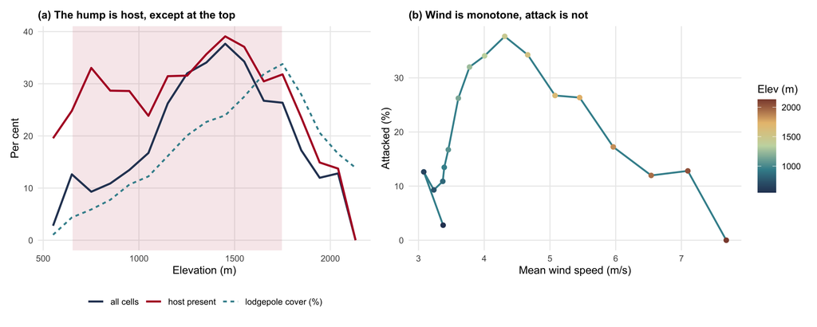

Figure 1: (a) Attack across the gradient, raw and conditioned on lodgepole presence, with mean lodgepole cover. Conditioning flattens the curve below 1,900 m and does not above it. (b) The same data against wind speed: wind rises monotonically with elevation while attack turns over, so no monotone wind relationship can hold across the gradient. Shading marks the elevation range of the 2 by 4 km clip.

```r
fine <- S |> mutate(b = cut(Elevation, breaks = seq(500, 2350, 100))) |>
  group_by(b) |>
  summarise(el = mean(Elevation), raw = 100*mean(Attacked), pine = mean(PinePct),
            wind = mean(Wind), n = n(),
            cond = ifelse(sum(HasHost) > 150, 100*mean(Attacked[HasHost]), NA_real_),
            .groups = "drop") |> filter(n > 300)
crng <- range(S$Elevation[S$InClip == 1])

pa <- ggplot(fine) +
  annotate("rect", xmin = crng[1], xmax = crng[2], ymin = -Inf, ymax = Inf,
           fill = "#b2182b", alpha = .10) +
  geom_line(aes(el, raw,  colour = "all cells"), linewidth = .9) +
  geom_line(aes(el, cond, colour = "host present"), linewidth = .9) +
  geom_line(aes(el, pine, colour = "lodgepole cover (%)"), linetype = "22", linewidth = .8) +
  scale_colour_manual(values = c("all cells" = "#2b4162", "host present" = "#b2182b",
                                 "lodgepole cover (%)" = "#3f8f9b"), name = NULL) +
  labs(x = "Elevation (m)", y = "Per cent", title = "(a) The hump is host, except at the top") +
  theme(legend.position = "bottom")

pb <- ggplot(fine, aes(wind, raw)) +
  geom_path(colour = "#3f8f9b", linewidth = .8) +
  geom_point(aes(colour = el), size = 1.8) +
  scale_colour_gradientn(colours = c("#2b4162","#3f8f9b","#c6d8af","#e8c07d","#8c4b3c"),
                         name = "Elev (m)") +
  labs(x = "Mean wind speed (m/s)", y = "Attacked (%)",
       title = "(b) Wind is monotone, attack is not")
pa + pb
```

## 4.2 The Krawchuk test

```r
mt_h <- model_table(ZH)
fmt_model(mt_h) |> kable(booktabs = TRUE, align = "lrrrrc") |>
  kable_styling(full_width = FALSE, font_size = 10)
```

| Term | beta | naive z | block 95% CI | sign stability | Supported |
| --- | --- | --- | --- | --- | --- |
| Elevation | -0.130 | -19.2 | [-0.396, +0.172] | 0.83 | no |
| WindResid | -0.176 | -26.8 | [-0.390, +0.037] | 0.95 | no |
| PinePct | +0.177 | +28.0 | [+0.046, +0.319] | 1.00 | yes |
| Basal | +0.028 | +4.3 | [-0.171, +0.199] | 0.65 | no |
| TPI600 | +0.002 | +0.4 | [-0.097, +0.111] | 0.53 | no |
| Slope | +0.004 | +0.5 | [-0.148, +0.152] | 0.50 | no |
| TWI | -0.010 | -1.5 | [-0.094, +0.050] | 0.61 | no |
| RIX | -0.024 | -3.8 | [-0.069, +0.022] | 0.84 | no |

```r
wr <- mt_h[mt_h$term == "WindResid", ]
pp <- mt_h[mt_h$term == "PinePct", ]
```

Restricted to cells that contain host, the orthogonalised wind term is the largest negative coefficient in the model, -0.176 per standard deviation, comparable in magnitude to the positive effect of lodgepole cover itself at +0.177 (Table 4). Its sign is reproduced in 95 per cent of spatial block resamples. Its 95 per cent block interval, however, runs [-0.390, +0.037] and reaches zero.

On this fit the hypothesis is supported in direction and unresolved in magnitude. The descriptive result in Section 4.1 is not in doubt: attack halves at the top of the gradient while host cover does not fall. What is in doubt is whether the wind surface is the right explanation for it, and with roughly 175 independent 1 km blocks in this landscape the binary response cannot settle it. Host cover is the only term whose interval excludes zero, and it does so in the expected direction.

That verdict is a property of the response coding rather than of the data, and Section 4.3 revisits it. We report the binary model first because it is the form the refugia literature uses, and because the comparison between the two is itself a result.

Note also that elevation, entered alongside the orthogonalised wind term, is itself negative and unsupported. Once host is in the model the remaining elevation signal is weak; the suppression at the top of the gradient is not simply an elevation effect.

## 4.3 Severity carries the signal the binary discards

```r
## Fitted only to show what a single proportional-odds summary conceals; the
## threshold-specific fits in @tbl-ordinal are the result.
zo <- ZH; zo$sev <- factor(pmin(zo$Severity, 4L), levels = 0:4, ordered = TRUE)
polr_fit <- MASS::polr(sev ~ Elevation + WindResid + PinePct + Basal +
                             TPI600 + Slope + TWI + RIX,
                       data = zo, method = "logistic", Hess = FALSE)
```

```r
CUTS <- tibble(k = 1:4,
               label = c("trace or worse", "light or worse",
                         "moderate or worse", "severe or worse"))

cum <- lapply(seq_len(nrow(CUTS)), function(i) {
  z <- ZH; z$y <- as.integer(z$Severity >= CUTS$k[i])
  fit <- fit_fast(design_matrix(z), z$y)
  bs  <- block_boot(z)
  q   <- quantile(bs[, "WindResid"], c(.025, .975), na.rm = TRUE)
  tibble(Threshold = CUTS$label[i], Cells = sum(z$y),
         `Wind residual beta` = coef(fit)[["WindResid"]],
         lo = q[1], hi = q[2],
         `sign stability` = mean(sign(bs[, "WindResid"]) ==
                                 sign(coef(fit)[["WindResid"]]), na.rm = TRUE),
         `Pine cover beta` = coef(fit)[["PinePct"]],
         `Elevation beta`  = coef(fit)[["Elevation"]])
}) |> bind_rows()

cum |> transmute(Threshold, Cells,
                 `Wind residual beta` = sprintf("%+.3f", `Wind residual beta`),
                 `block 95% CI` = sprintf("[%+.3f, %+.3f]", lo, hi),
                 `sign stability` = sprintf("%.2f", `sign stability`),
                 `Pine cover beta` = sprintf("%+.3f", `Pine cover beta`),
                 Supported = ifelse(lo * hi > 0, "yes", "no")) |>
  kable(booktabs = TRUE, align = "lrrrrrc", format.args = list(big.mark = ",")) |>
  kable_styling(full_width = FALSE, font_size = 10)
```

Table 5: Cumulative logits at each severity threshold, cells containing lodgepole pine only. Each row is the same model fitted to a harder threshold. The orthogonalised wind coefficient strengthens monotonically as the threshold rises and its block interval excludes zero at every threshold above trace, which the binary attacked model does not show.

| Threshold | Cells | Wind residual beta | block 95% CI | sign stability | Pine cover beta | Supported |
| --- | --- | --- | --- | --- | --- | --- |
| trace or worse | 38,473 | -0.176 | [-0.390, +0.037] | 0.95 | +0.177 | no |
| light or worse | 34,839 | -0.203 | [-0.418, -0.015] | 0.98 | +0.204 | yes |
| moderate or worse | 13,862 | -0.390 | [-0.674, -0.066] | 0.99 | +0.243 | yes |
| severe or worse | 1,522 | -1.002 | [-1.552, -0.169] | 0.98 | -0.101 | yes |

Collapsing the response to attacked or not costs the study its main result. Fitted at successively harder severity thresholds, the orthogonalised wind coefficient does not stay put: it strengthens monotonically from -0.176 at trace or worse to -1.002 at severe or worse, a 5.7-fold increase (Table 5). At every threshold above trace the block interval excludes zero. The first row is the binary model of Section 4.2 restated, since a cell reaching trace or worse is exactly a cell recorded as attacked, so the table is a strict extension of that fit rather than a competing one. It is also the weakest of the four, and it is the one the refugia literature would conventionally have reported.

This is a dose-response gradient of the shape the hypothesis predicts. Wherever the wind surface has a component independent of elevation, that component is associated with less attack, and the association is strongest where attack was heaviest. It also explains the binary result: a cell that reached trace severity is barely distinguishable from an unattacked cell, so a threshold drawn between them puts most of the noise in the response exactly where the model is asked to fit.

We are nonetheless not able to attribute the gradient to wind rather than to cold, and the Discussion explains why the ordinal result does not help with that. What has changed is the statistical support, not the identification.

## 4.4 Aspect separates thermal load from exposure, partly

```r
FULLV <- c(MODEL_VARS, EXTRA)
ZHx   <- ZH[complete.cases(ZH[, FULLV]), ]

## Ten terms and 1,522 events cannot be fitted together: the severe threshold
## drives fitted probabilities to numerical zero. We detect that rather than
## report the resulting coefficients, and the severe row is dropped below.
sep_check <- function(z, vars, k) {
  z$y <- as.integer(z$Severity >= k)
  p <- fit_fast(design_matrix(z, vars), z$y)$fitted.values
  sum(p < 1e-6 | p > 1 - 1e-6)
}
sep <- sapply(1:4, function(k) sep_check(ZHx, FULLV, k))
names(sep) <- c("trace+","light+","moderate+","severe+")
OK_CUTS <- which(sep == 0)

asp_tab <- lapply(OK_CUTS, function(k) {
  z <- ZHx; z$y <- as.integer(z$Severity >= k)
  fit <- fit_fast(design_matrix(z, FULLV), z$y); bs <- block_boot(z, FULLV)
  ci <- function(n) quantile(bs[, n], c(.025, .975), na.rm = TRUE)
  one <- function(n) sprintf("%+.3f [%+.3f, %+.3f]", coef(fit)[[n]], ci(n)[1], ci(n)[2])
  tibble(Threshold = CUTS$label[k], Cells = sum(z$y),
         `Wind residual` = one("WindResid"), `Heat load` = one("HLI"),
         `Shelter` = one("SxMean"))
}) |> bind_rows()

asp_tab |> kable(booktabs = TRUE, align = "lrrrr",
                 format.args = list(big.mark = ",")) |>
  kable_styling(full_width = FALSE, font_size = 9)
```

| Threshold | Cells | Wind residual | Heat load | Shelter |
| --- | --- | --- | --- | --- |
| trace or worse | 38,473 | -0.214 [-0.424, +0.002] | +0.106 [-0.116, +0.331] | -0.153 [-0.253, -0.024] |
| light or worse | 34,839 | -0.234 [-0.441, -0.050] | +0.043 [-0.198, +0.274] | -0.152 [-0.262, -0.031] |
| moderate or worse | 13,862 | -0.505 [-0.804, -0.184] | +0.625 [+0.301, +1.030] | -0.013 [-0.144, +0.131] |

Second, it leaves the wind result standing. The orthogonalised wind coefficient does not weaken when heat load is controlled for; it strengthens slightly at every threshold. Whatever the wind residual is tracking, it is not simply the warm-aspect effect in disguise.

Third, and least comfortably, the two exposure measures disagree. The shelter index is negative, meaning sheltered ground carries *less* attack and exposed ground more, which is the opposite of what the orthogonalised wind term says and the opposite of what Krawchuk et al. (2020) predict. The two are only weakly correlated with each other (-0.22), so they are not two measurements of one quantity that happen to disagree; they are measuring different things, and only one of them is a direct geometric description of exposure. We take this as evidence against treating any single surface as “wind exposure” and reporting its coefficient as though the phrase had one referent. It is also a caution against our own result: the wind residual’s negative sign is not corroborated by the one predictor in this study that describes exposure geometrically rather than by downscaling.

The severe threshold is absent from Table 6 because ten terms and 1522 events drive the fit into quasi-separation, with 14,466 cells at numerically zero fitted probability. The eight-term model of Table 5 is free of this at every threshold, which is why that table retains its severe row and this one does not.

## 4.5 Observed winter minima do not reach the lethal threshold

```r
st <- read.csv(here("02.inputs/climate/station-winter-minima.csv"), stringsAsFactors = FALSE)

## The censoring rule is applied here rather than taken on trust from the
## retrieval script. Many older British Columbia Wildfire Service sensors floor
## at exactly -20.0 C. A station-winter is unusable when its minimum sits
## exactly on that floor, because the true minimum is then unknown. A minimum
## colder than the floor shows the sensor did read past it, so readings at
## -20.0 in those winters are real measurements and the winter is kept. The
## floor is a sensor artefact of that network, so the rule does not touch the
## Environment and Climate Change Canada records.
FLOOR <- -20
st$censored <- st$network == "BCWS" &
               abs(st$min_temp_c - FLOOR) < 1e-6 &
               st$n_at_minus20 > 0
stopifnot(identical(st$censored, as.logical(st$censored_flag)))

## Isolated single-observation spikes are rejected at the observation level by
## the retrieval script, which is the only stage holding the sub-daily series a
## per-winter summary cannot carry; `min_temp_c_usable` is that de-spiked
## minimum. Everything else about the screen is visible above.
use <- st[!st$censored & !is.na(st$min_temp_c_usable), ]

use$band <- cut(use$elevation_m, c(0, 800, 1500, 2500),
                labels = c("below 800 m", "800 to 1,500 m", "above 1,500 m"))
use |> group_by(band) |>
  summarise(Stations = n_distinct(station_name), `Station-winters` = n(),
            `Coldest (°C)` = min(min_temp_c_usable),
            `Mean minimum (°C)` = round(mean(min_temp_c_usable), 1),
            .groups = "drop") |>
  kable(booktabs = TRUE, align = "lrrrr") |>
  kable_styling(full_width = FALSE, font_size = 10)
```

Table 7: Observed winter minimum air temperatures from weather stations within 100 km, by elevation band, after excluding station-winters censored at the -20.0 °C sensor floor. Nothing in the record approaches the temperatures conventionally cited as lethal for this insect. Elevation orders the minima only weakly, which is cold-air pooling.

| band | Stations | Station-winters | Coldest (°C) | Mean minimum (°C) |
| --- | --- | --- | --- | --- |
| below 800 m | 16 | 212 | -28.2 | -15.9 |
| 800 to 1,500 m | 9 | 109 | -26.9 | -17.4 |
| above 1,500 m | 3 | 26 | -28.7 | -19.4 |

```r
coldest  <- use[which.min(use$min_temp_c_usable), ]
hi       <- use[use$elevation_m >= 1500, ]
lowcold  <- use[use$elevation_m < 800, ]
lowcold  <- lowcold[which.min(lowcold$min_temp_c_usable), ]
```

The cold explanation for the high-elevation suppression assumes it gets cold enough up there to kill beetles. That is checkable against observation, and it does not hold. Across 347 station-winters from 28 stations spanning 435 to 2423 m, retrieved and screened by the script in `02.inputs/climate/`, the coldest defensible winter minimum anywhere in the region is -28.7 °C, at norns at 2,423 m in winter 2014. The number of station-winters reaching -35 °C or colder is 0, and the number reaching -40 °C or colder is 0. Above 1,500 m the mean winter minimum is -19.4 °C. The lethal temperatures conventionally cited for mountain pine beetle larvae sit near -40 °C in air, and around -37 °C under bark (Cooke, 2009; Safranyik & Wilson, 2006), roughly ten degrees colder than anything this record contains.

Two features of the record matter for the argument. Elevation orders these minima only weakly: grand forks, at 630 m, reaches -28.2 °C, within 0.5 °C of the alpine station 1,793 m higher. That is cold-air pooling, and it is the reason temperature cannot be treated as a linear function of elevation here. And 16 station-winters had to be set aside because the sensors floor at exactly -20.0 °C, a censoring artefact concentrated before 2008; taking a naive minimum over those would have manufactured a threshold that is not in the data.

This is a plausibility check and not a temperature surface. No station inside the study area reported during the outbreak window, and the stations that do report are spread across roughly 100 km of separate massifs, so these values bound the regional cold climate rather than map it. Within that limit the conclusion is reasonably firm: direct freeze mortality is unlikely to be what suppresses attack at the top of this gradient.

## 4.6 Extent decides the sign

```r
extent_row <- function(z, lab) {
  r2  <- summary(lm(Wind ~ Elevation, data = z))$r.squared
  fit <- fit_fast(design_matrix(z), z$y)
  bs  <- block_boot(z)
  q   <- quantile(bs[, "WindResid"], c(.025, .975), na.rm = TRUE)
  tibble(Extent = lab, Cells = nrow(z),
         `R² wind on elevation` = round(r2, 3),
         `VIF` = round(1/(1-r2), 1),
         `Wind residual beta` = sprintf("%+.3f", coef(fit)[["WindResid"]]),
         `block 95% CI` = sprintf("[%+.3f, %+.3f]", q[1], q[2]))
}
bind_rows(
  extent_row(Z,  sprintf("full landscape (%.0f km²)", nrow(S)*prod(res(G))/1e6)),
  extent_row(ZH, "landscape, host present"),
  extent_row(ZC, "2 by 4 km clip (8 km²)")
) |> kable(booktabs = TRUE, align = "lrrrrr", format.args = list(big.mark = ",")) |>
  kable_styling(full_width = FALSE, font_size = 10)
```

Table 8: The same model fitted at three extents. As the analysis area shrinks, the share of wind variance explained by elevation rises and the orthogonalised wind coefficient reverses sign. The 2 by 4 km clip is the extent at which the companion study was run and is typical of disturbance ecology generally.

| Extent | Cells | R² wind on elevation | VIF | Wind residual beta | block 95% CI |
| --- | --- | --- | --- | --- | --- |
| full landscape (168 km²) | 266,650 | 0.629 | 2.7 | -0.304 | [-0.521, -0.098] |
| landscape, host present | 127,604 | 0.617 | 2.6 | -0.176 | [-0.390, +0.037] |
| 2 by 4 km clip (8 km²) | 9,784 | 0.797 | 4.9 | +0.239 | [-1.260, +0.921] |

The confound is a function of extent, and so is the answer. Across the landscape elevation explains 63 per cent of the variance in the wind surface; inside the 2 by 4 km clip it explains 80 per cent (Table 8). The orthogonalised wind coefficient is negative at landscape extent and **positive** inside the clip.

This is the paper’s firmest result and it does not depend on resolving the Krawchuk hypothesis. The same response, the same predictors and the same model, fitted to a subset of the same landscape, return opposite signs on the term of interest. A study of this system conducted at the extent at which disturbance ecology is usually conducted would have concluded that beetle attack increases with wind exposure. At landscape extent the same data say the opposite.

## 4.7 Grain does not decide it

```r
CONT <- c("Elevation","Slope","TWI","RIX","Wind","PinePct","Basal")
base_stack <- c(terr[[c("Elevation","Slope","TWI","RIX","Wind")]],
                host[[c("PinePct","Basal")]], severity, in_clip)
names(base_stack) <- c(CONT, "Severity", "InClip")

## fact is the aggregation factor from the native 25 m grid.
build_grain <- function(fact) {
  b <- if (fact == 1L) base_stack else
       c(aggregate(base_stack[[CONT]], fact, fun = "mean", na.rm = TRUE),
         aggregate(base_stack[[c("Severity","InClip")]], fact, fun = "max", na.rm = TRUE))
  Gi <- b[["Elevation"]]; rs <- res(Gi)[1]
  w  <- max(3L, as.integer(2 * floor(625 / rs / 2) + 1))   # odd window nearest 625 m
  b$TPI600 <- tpi(Gi, w)
  d <- as.data.frame(b, na.rm = FALSE)
  d$Attacked <- d$Severity > 0
  d$HasHost  <- !is.na(d$PinePct) & d$PinePct > 0
  blk <- max(1L, as.integer(round(BLOCK / fact)))          # blocks stay near 1 km
  rc  <- rowColFromCell(Gi, seq_len(ncell(Gi)))
  d$block <- paste(rc[,1] %/% blk, rc[,2] %/% blk, sep = "_")
  d <- d[complete.cases(d[, MVARS]), ]
  structure(d, res = rs, win = w * rs)
}

grain_row <- function(fact) {
  d  <- build_grain(fact); h <- d[d$HasHost, ]
  z  <- standardise(h)
  r2 <- summary(lm(Wind ~ Elevation, data = z))$r.squared
  fit <- fit_fast(design_matrix(z), z$y); bs <- block_boot(z)
  q  <- quantile(bs[, "WindResid"], c(.025, .975), na.rm = TRUE)
  tibble(Grain = sprintf("%.0f m", attr(d, "res")),
         `TPI window` = sprintf("%.0f m", attr(d, "win")),
         `Host cells` = nrow(h), Blocks = length(unique(z$block)),
         `R² wind on elevation` = round(r2, 3),
         `Wind residual beta` = sprintf("%+.3f", coef(fit)[["WindResid"]]),
         `block 95% CI` = sprintf("[%+.3f, %+.3f]", q[1], q[2]),
         `sign stability` = sprintf("%.2f",
           mean(sign(bs[, "WindResid"]) == sign(coef(fit)[["WindResid"]]), na.rm = TRUE)))
}

## The 25 m row must reproduce the analysis frame built in `assemble`; if this
## assertion ever fails the two code paths have drifted apart.
stopifnot(nrow(build_grain(1L)) == nrow(S))

bind_rows(lapply(c(1L, 2L, 4L), grain_row)) |>
  kable(booktabs = TRUE, align = "llrrrrrr", format.args = list(big.mark = ",")) |>
  kable_styling(full_width = FALSE, font_size = 10)
```

Table 9: The host-present model refitted at three grains. Predictors are aggregated by mean, severity class by maximum, the topographic position neighbourhood is held near-constant in metres, and the bootstrap blocks are rescaled to stay near 1 km. Unlike extent, grain changes nothing: the collinearity, the sign and the magnitude are all stable across a four-fold change in cell size.

| Grain | TPI window | Host cells | Blocks | R² wind on elevation | Wind residual beta | block 95% CI | sign stability |
| --- | --- | --- | --- | --- | --- | --- | --- |
| 25 m | 628 m | 127,604 | 175 | 0.617 | -0.176 | [-0.390, +0.037] | 0.95 |
| 50 m | 653 m | 35,249 | 175 | 0.619 | -0.183 | [-0.396, +0.014] | 0.96 |
| 100 m | 703 m | 10,260 | 178 | 0.620 | -0.208 | [-0.413, -0.026] | 0.98 |

Work et al. (2011), working on carabid beetles, found that the apparent importance of terrain derivatives changed with the resolution at which they were computed, because elevation error propagates into derived curvature differently at every grain. The concern transfers directly and is worth separating from extent, because the two are routinely confused.

Here they behave quite differently (Table 9). Aggregating the analysis from 25 m to 100 m, a sixteen-fold reduction in the number of cells, leaves the confound essentially untouched: elevation explains close to the same share of wind variance at every grain. The orthogonalised wind coefficient neither reverses nor decays, and its sign stability rises rather than falls. The suppression at the top of the gradient is a landscape-scale feature and it survives being looked at through a coarser lens.

The contrast with Section 4.6 is the point. Enlarging the cell by a factor of four changes almost nothing; shrinking the study area to 8 km2 changes the sign of the term the paper is about. Grain governs how finely a pattern is resolved, extent governs which part of the joint distribution of elevation and wind the model ever sees, and only the second is capable of reversing an inference. It follows that reporting the resolution of an analysis, which is near-universal practice, is not a substitute for reporting its extent, which is not.

# 5 Discussion

## 5.1 What can and cannot be concluded about refugia

The high-elevation suppression is real and it is not host limitation. Among cells carrying lodgepole pine, attack above 1,850 m runs at 15.3 per cent against 32.3 per cent below, while mean pine cover in those cells is slightly higher and basal area is roughly a fifth lower. Under the Krawchuk et al. (2020) definition these are refugia: locations disturbed less severely than the surrounding landscape, with host present, and predictably located by an enduring topographic feature. They match Cartwright (2018) in associating refugia with thinner stands.

What we cannot do is attribute them to wind, and it is worth being precise about why, because the ordinal result in Section 4.3 changes one half of the difficulty and leaves the other exactly where it was.

The statistical half is much improved. Once severity is modelled as the ordinal variable it is, the orthogonalised wind term clears the interval test at every threshold above trace and strengthens monotonically with severity. Had we followed the convention of the refugia literature and reported the binary fit alone, we would have described the strongest and most orderly relationship in the study as a null result. Krawchuk et al. (2020) warn against binary refugia coding on conceptual grounds; the warning turns out to have a statistical edge as well.

The identification half is untouched. The upper gradient is also where it is coldest, and cold limits this beetle through overwinter mortality and through the degree-day accumulation required for univoltine development (Carroll & Safranyik, 2003; Cooke, 2009; Safranyik & Wilson, 2006). Crucially, cold predicts a dose-response in severity just as wind disruption does: fewer beetles surviving the winter means both fewer stands attacked and lighter attack in those that are. The monotone strengthening across thresholds is therefore fully consistent with cold limitation and does nothing to separate the two. Orthogonalising against elevation removes the linear elevation component of the wind surface, but it does not orthogonalise against temperature, which is not a linear function of elevation in a landscape with cold-air pooling.

We looked for a way out and do not think one exists at this extent. Separating exposure from cold needs a temperature surface whose fine-scale structure is not itself a function of the elevation model, and any surface of the form intercept plus lapse rate times elevation is an affine rescaling of the elevation layer no matter whether the lapse rate came from a physical constant or from real thermometers. It is collinear by construction and contributes nothing the elevation term does not already carry. Only a residual departure from that form would identify anything, and mapping such a residual across this landscape would itself require terrain as the interpolator. The gridded products with genuine sub-kilometre temperature structure all obtain it by regression or lapse rate onto a digital elevation model, so they reproduce the problem rather than solve it, and satellite land surface temperature is a nighttime and cloud-limited observation whose topographic correction in rugged terrain takes a high-resolution elevation model as an input.

Two results narrow the problem without dissolving it, and they work together.

The first is that cold limitation here is almost certainly not freeze mortality. Section 4.5 shows that observed winter minima across the region fall roughly 11 degrees short of the temperatures conventionally cited as lethal for this insect, at every elevation for which there is a record. If larvae are not being killed outright, the cold mechanism that remains is the degree-day accumulation required to complete a generation in one year, which is a matter of accumulated warmth rather than of extreme events.

The second is that aspect gives purchase on exactly that. Because heat load is a trigonometric function of the elevation model rather than a field draped over it, it carries thermal information genuinely independent of elevation, and Section 4.4 finds it predicts attack severity strongly and in the direction warmth-limited development implies. The two results therefore point the same way: the thermal constraint that plausibly operates on this landscape is the one for which we have an elevation-independent proxy, and that proxy behaves as the constraint predicts.

This is a real gain and it is bounded in three ways. The station record is a regional plausibility check and not a temperature surface, since no station inside the study area reported during the outbreak window. Heat load is a modelled radiation load, not a measured temperature. And neither result touches the possibility that cold-air pooling produces local freeze events the regional station network never sampled, which is precisely the structure Section 4.5 shows is present when a valley station at 630 m matches an alpine station 1,793 m above it.

The deeper obstacle is that the quantity governing overwinter survival is not air temperature at all but temperature under the bark, which is not observed at landscape scale anywhere. Goodsman, Weber, & Bleiker (2024), validating the standard Canadian Forest Service winter mortality model against observed mortality in Banff National Park, found its spatial predictions poor and attributed the failure to precisely this: mountainous terrain is a hard prediction problem when under-bark temperatures are not measured directly. That is peer-reviewed confirmation that the confound we report unresolved is unresolved in this terrain generally, and not an artefact of our data being thin.

There is also a mechanism that would predict the opposite sign, and it should not be waved past. Smith-McKenna, Resler, Tomback, Zhang, & Malanson (2013), working on white pine blister rust in whitebark pine treeline communities, found infection concentrated in topographically sheltered positions and attributed it to exposed sites intercepting fewer wind-borne propagules: there, exposure protects by dispersal limitation rather than by disrupting a chemical signal. The agent is a fungus rather than an insect and the transport is passive rather than behavioural, so the analogy is not tight. But the two mechanisms are observationally identical in a static model, both predicting less damage on exposed convex ground for reasons that have nothing to do with pheromone plumes. Nothing in our design distinguishes them. Distinguishing them would need the dispersal process observed rather than inferred, through attack years, distance from the previous year’s attack, or trapping.

The honest summary is that we have located candidate refugia, confirmed the host-density half of the hypothesis, and found the wind half statistically well supported once severity is modelled properly, but still confounded with at least two alternative explanations on the same gradient.

## 5.2 The low-elevation trap

The result that should travel furthest is the one at the bottom of the gradient. Attack there is near zero, and any refugia mapping exercise that lacked a host layer would have identified the valley as a large, spatially coherent, topographically predictable refugium. It is not a refugium. It is a place with almost no pine. Conditioning on host raises attack in the lowest band from 6.5 per cent to 23.3 per cent, which is within the range observed at mid elevations.

Krawchuk et al. (2020) anticipate this in framing, asking of any candidate refugium both what it is a refugium from and what it is a refugium for, but the framework does not force the check and the data required to perform it are not always at hand. On this landscape the difference between performing it and not is the difference between reporting a 42 km2 valley refugium and reporting none. We would put the requirement more strongly than the framework currently does: a refugium claim without an independent host or habitat layer is not interpretable.

## 5.3 Extent, and the transferability of terrain-derived predictors

The sign reversal in Section 4.6 generalises beyond wind. The mechanism is that a fine-resolution climate surface is produced by imposing terrain on a coarse field, so wherever the coarse field is nearly constant the product approaches a function of the terrain. That covers most gridded climate products used in landscape ecology. Three properties govern the severity and all three are checkable before any model is fitted: the ratio of analysis extent to the correlation length of the driving field, the relief of the study area, and which terrain variable does the work in the downscaling, which for wind is elevation and roughness but for radiation would be slope and aspect.

The consequence for synthesis is uncomfortable. If the strength of a confound scales with study extent, effect sizes for derived climate predictors are not comparable across studies of different extents, and small studies will systematically report the strongest apparent effects. That is a pattern easily mistaken for publication bias.

We would ask three things of any study entering such a surface into a disturbance model: report its regression on elevation, report the same diagnostic at more than one extent, and interpret only the orthogonalised coefficient. None requires new data. In this study each of them changed the answer.

## 5.4 Limitations

The plot record calibrates severity but not location, because coordinates for the 28 ground plots were not recoverable from the project archive. The survey response is observer sketch-mapping with known positional and severity error, and rasterising polygons imposes a grain coarser than the 25 m analysis cell; the severity classes in particular are assigned by eye from an aircraft, so the ordinal gradient in Section 4.3 rests on an observer’s judgement of proportion killed rather than on measurement. The inventory is a modelled operational product, not a census, and its species percentages are polygon-level attributes applied uniformly within polygons. The grain test in Section 4.7 spans 25 m to 100 m, which brackets the resolutions in common use and the 900 m2 grain Krawchuk et al. (2020) propose as canonical for refugia, but it cannot speak to behaviour at the scale of the Landsat and Sentinel products a follow-up would likely use. Finally the analysis is correlational and the outbreak is one epidemic passage; frequency refugia in the sense of Krawchuk et al. (2020) cannot be addressed with a single outbreak window, and the static design cannot separate a wind effect on pheromone communication from a wind effect on dispersal itself.

The identification gained in Section 4.4 is partial in a specific and limiting sense. Heat load bears on the degree-day accumulation half of cold limitation, the half that governs whether a generation completes in one year. It says almost nothing about the overwinter minimum half, the lethal cold events that kill larvae outright, because those are driven by synoptic air mass intrusions and cold-air pooling rather than by radiation on a slope. A model that separates warm aspects from cool ones at the same elevation has therefore addressed one of the two thermal mechanisms and left the other untouched, and the separation rests on an assumed functional form, the McCune & Keon (2002) equation, rather than on an independent measurement. Testing the overwinter half still requires temperature data this landscape does not have.

The shelter index is also imperfect as a test of the mechanism. It is omnidirectional because the Global Wind Atlas supplies no wind direction, and an omnidirectional shelter index cannot represent a process that depends on where the wind actually comes from. A directional index computed on a known prevailing bearing would be a sharper instrument, and its disagreement with the wind residual might resolve in either direction under one.

# 6 Conclusions

Beetle-caused mortality at Darkwoods is unimodal across 1,776 m of relief. Below 1,900 m that pattern is the distribution of lodgepole pine, and conditioning on host removes almost all of it. Above 1,900 m it is not: attack halves while host cover holds and stands thin, which is where the Krawchuk refugia hypothesis predicts refugia should be.

The component of the Global Wind Atlas surface that is independent of elevation is the strongest negative predictor of attack in host-bearing stands. Coded as a binary its interval reaches zero; modelled as the ordinal severity class it is, it clears the interval test at every threshold above trace and strengthens monotonically as attack gets heavier. The statistical support is therefore good and the ecological attribution is still not settled, because cold limitation and simple dispersal interception both predict the same gradient and neither can be ruled out with a static model on one mountain.

The methodological findings are firmer, and all three are failures of design rather than of data. Fitted inside a 2 by 4 km clip of the same landscape, the wind coefficient changes sign, while a four-fold change of grain moves it hardly at all: extent is the axis that decides inferences here, and it is the one studies routinely leave unreported. Collapsing severity to attacked or not converts the study’s clearest relationship into a null. And without a host layer, the pine-poor valley floor would have been mapped as the largest refugium on the mountain.

# 7 References

Badger, J., Frank, H., Hahmann, A. N., & Giebel, G. (2014). [Wind-climate estimation based on mesoscale and microscale modeling: Statistical–dynamical downscaling for wind energy applications](https://doi.org/10.1175/JAMC-D-13-0147.1). *Journal of Applied Meteorology and Climatology*, *53*(8), 1901–1919.

Beers, T. W., & Miller, C. I. (1973). *Manual of forest mensuration*. T; C Enterprises.

Braumandl, T. F., & Dykstra, P. R. (2005). *A field guide for site identification and interpretation for the Nelson Forest Region: Supplement 1* ( No. Land Management Handbook 20, Supplement 1). Victoria, British Columbia: British Columbia Ministry of Forests; Range, Forest Science Program.

Carroll, A. L., & Safranyik, L. (2003). The bionomics of the mountain pine beetle in lodgepole pine forests: Establishing a context. *Mountain pine beetle symposium: Challenges and solutions, october 30–31, 2003, kelowna, british columbia* (pp. 21–32). Victoria, British Columbia: Natural Resources Canada, Canadian Forest Service, Pacific Forestry Centre.

Cartwright, J. M. (2018). [Landscape topoedaphic features create refugia from drought and insect disturbance in a lodgepole and whitebark pine forest](https://doi.org/10.3390/f9110715). *Forests*, *9*(11), 715.

Cooke, B. J. (2009). *Forecasting mountain pine beetle overwintering mortality in a variable environment* ( No. Mountain Pine Beetle Working Paper 2009-03). Victoria, British Columbia: Natural Resources Canada, Canadian Forest Service, Pacific Forestry Centre.

Goodsman, D. W., Weber, J. D., & Bleiker, K. P. (2024). [An evaluation of a winter mortality model for the mountain pine beetle](https://doi.org/10.3390/f15081425). *Forests*, *15*(8), 1425.

Gray, B., Billings, R. F., Gara, R. I., & Johnsey, R. L. (1972). On the emergence and initial flight behaviour of the mountain pine beetle, Dendroctonus ponderosae, in eastern Washington. *Zeitschrift für angewandte Entomologie*, *71*.

Hadley, K. S. (1994). [The role of disturbance, topography, and forest structure in the development of a montane forest landscape](https://doi.org/10.2307/2996883). *Bulletin of the Torrey Botanical Club*, *121*(1), 47–61.

Jones, K. L., Shegelski, V. A., Marculis, N. G., Wijerathna, A. N., & Evenden, M. L. (2019). [Factors influencing dispersal by flight in bark beetles (Coleoptera: Curculionidae: Scolytinae): From genes to landscapes](https://doi.org/10.1139/cjfr-2018-0304). *Canadian Journal of Forest Research*, *49*, 1024–1041.

Ketcheson, M. V., Braumandl, T. F., Meidinger, D., Utzig, G., Demarchi, D. A., & Wikeem, B. M. (1991). Interior cedar – hemlock zone. In D. V. Meidinger & J. Pojar (Eds.), *Ecosystems of British Columbia*, Special report series (pp. 167–181). Victoria, British Columbia: Research Branch, British Columbia Ministry of Forests.

Krawchuk, M. A., Meigs, G. W., Cartwright, J. M., Coop, J. D., Davis, R., Holz, A., Kolden, C., et al. (2020). [Disturbance refugia within mosaics of forest fire, drought, and insect outbreaks](https://doi.org/10.1002/fee.2190). *Frontiers in Ecology and the Environment*, *18*(5), 235–244.

McCune, B., & Keon, D. (2002). [Equations for potential annual direct incident radiation and heat load](https://doi.org/10.1111/j.1654-1103.2002.tb02087.x). *Journal of Vegetation Science*, *13*(4), 603–606.

Meddens, A. J. H., Hicke, J. A., Vierling, L. A., & Hudak, A. T. (2013). [Evaluating methods to detect bark beetle-caused tree mortality using single-date and multi-date Landsat imagery](https://doi.org/10.1016/j.rse.2013.01.002). *Remote Sensing of Environment*, *132*, 49–58.

Murphy, S., Leslie, A., Banks, L. K., & Wilson, J. (2024). *Spatial and temporal patterns of conifer regeneration following mountain pine beetle outbreak (*dendroctonus ponderosae*) and mixed-severity wildfire: A point process model of disturbance interactions in the Darkwoods Conservation Area*.

Natural Resources Canada. (2017). High resolution digital elevation model (HRDEM). Geospatial data product, Government of Canada.

Parker, A. J. (1982). [The topographic relative moisture index: An approach to soil-moisture assessment in mountain terrain](https://doi.org/10.1080/02723646.1982.10642224). *Physical Geography*, *3*(2), 160–168.

Safranyik, L., & Wilson, B. (Eds.). (2006). *The mountain pine beetle: A synthesis of biology, management, and impacts on lodgepole pine*. Victoria, British Columbia: Natural Resources Canada, Canadian Forest Service, Pacific Forestry Centre.

Smith-McKenna, E. K., Resler, L. M., Tomback, D. F., Zhang, H., & Malanson, G. P. (2013). [Topographic influences on the distribution of white pine blister rust in Pinus albicaulis treeline communities](https://doi.org/10.2980/20-3-3599). *Écoscience*, *20*(3), 215–229.

Technical University of Denmark (DTU) Wind Energy and World Bank Group. (n.d.). Global wind atlas: Mean wind speed at 10 m above ground level. https://globalwindatlas.info.

Wang, L., & Liu, H. (2006). An efficient method for identifying and filling surface depressions in digital elevation models for hydrologic analysis and modelling. *International Journal of Geographical Information Science*, *20*(2), 193–213. Taylor; Francis.

White, J. C., Wulder, M. A., Brooks, D., Reich, R., & Wheate, R. D. (2005). [Detection of red attack stage mountain pine beetle infestation with high spatial resolution satellite imagery](https://doi.org/10.1016/j.rse.2005.03.007). *Remote Sensing of Environment*, *96*, 340–351.

Winstral, A., Elder, K., & Davis, R. E. (2002). Spatial snow modeling of wind-redistributed snow using terrain-based parameters. *Journal of Hydrometeorology*, *3*(5), 524–538.

Work, T. T., St. Onge, B., & Jacobs, J. M. (2011). [Response of female beetles to LIDAR derived topographic variables in Eastern boreal mixedwood forests (Coleoptera, Carabidae)](https://doi.org/10.3897/zookeys.147.2013). *ZooKeys*, *147*, 623–639.

Ye, S., Rogan, J., Zhu, Z., Hawbaker, T. J., Hart, S. J., Andrus, R. A., Meddens, A. J. H., et al. (2021). [Detecting subtle change from dense Landsat time series: Case studies of mountain pine beetle and spruce beetle disturbance](https://doi.org/10.1016/j.rse.2021.112560). *Remote Sensing of Environment*, *263*, 112560.